# Homework #5: Density Estimation

Nicholas Keeley

Due: Thu Oct 21 | 3:25pm

NOTE: I referenced Lecture 14 for the KDE code in this assignment, and consulted classmate Geoff Hansen on the derivation math for problem 1.a.

**DS 6030 | Fall 2021 | University of Virginia**

# Required R packages and Directories

```r
data.dir = 'https://mdporter.github.io/DS6030/data/' # data directory
library(R6030)     # functions for SYS-6018
library(ks)        # functions for KDE
library(tidyverse) # functions for data manipulation
```

# Problem 1 Geographic Profiling

Geographic profiling, a method developed in criminology, can be used to estimate the [home location (roost) of animals](https://www.sciencedirect.com/science/article/pii/S0022519305004157) based on a collection of sightings. The approach requires an estimate of the distribution the animal will travel from their roost to forage for food.

A sample of $283$ distances that pipistrelle bats traveled (in meters) from their roost can be found at:

- **Bat Data**: https://mdporter.github.io/DS6030/data/geo_profile.csv

One probability model for the distance these bats will travel is:
$$\begin{align*}
f(x; \theta) = \frac{x}{\theta} \exp \left( - \frac{x^2}{2 \theta} \right)
\end{align*}$$
where the parameter $\theta > 0$ controls how far they are willing to travel.

## a. Derive the MLE for $\theta$ (i.e., show the math).

$$\begin{align*}
\ln(L(\theta)) = \sum_{i=1}^{n} \ln(f(x_{i}; \theta))
\end{align*}$$

$$\begin{align*}
1) \hspace{12pt} = \ln(\frac{x_{i}}{\theta} + \ln \exp \left( - \frac{x_{i}^2}{2 \theta} \right)
\end{align*}$$

$$\begin{align*}
2) \hspace{12pt} = \ln(x_{i}) - \ln(\theta) - \left(\frac{x_{i}^2}{2 \theta} \right)
\end{align*}$$

$$\begin{align*}
3) \hspace{12pt} \frac{\partial}{\partial \theta} \sum_{i=1}^{n} \ln(x) - \ln(\theta) - \left(\frac{x^2}{2 \theta} \right) = \sum_{i=1}^{n} -\frac{1}{\theta} + \left(\frac{x^2}{2 \theta^2} \right)
\end{align*}$$

$$\begin{align*}
4) \hspace{12pt} \theta_{MAX} = \sum_{i=1}^{n} -\frac{1}{\theta} + \left(\frac{x^2}{2 \theta^2} \right) = 0
\end{align*}$$

$$\begin{align*}
5) \hspace{12pt} = \frac{1}{2\theta} \sum_{i=1}^{n} x^2 = \frac{n}{\theta}
\end{align*}$$

$$\begin{align*}
6) \hspace{12pt} \theta_{MAX} = \frac{1}{2n} \sum_{i=1}^{n} x^2
\end{align*}$$

## b. What is the MLE of $\theta$ for the bat data? (Use results from a, or use computational methods.)

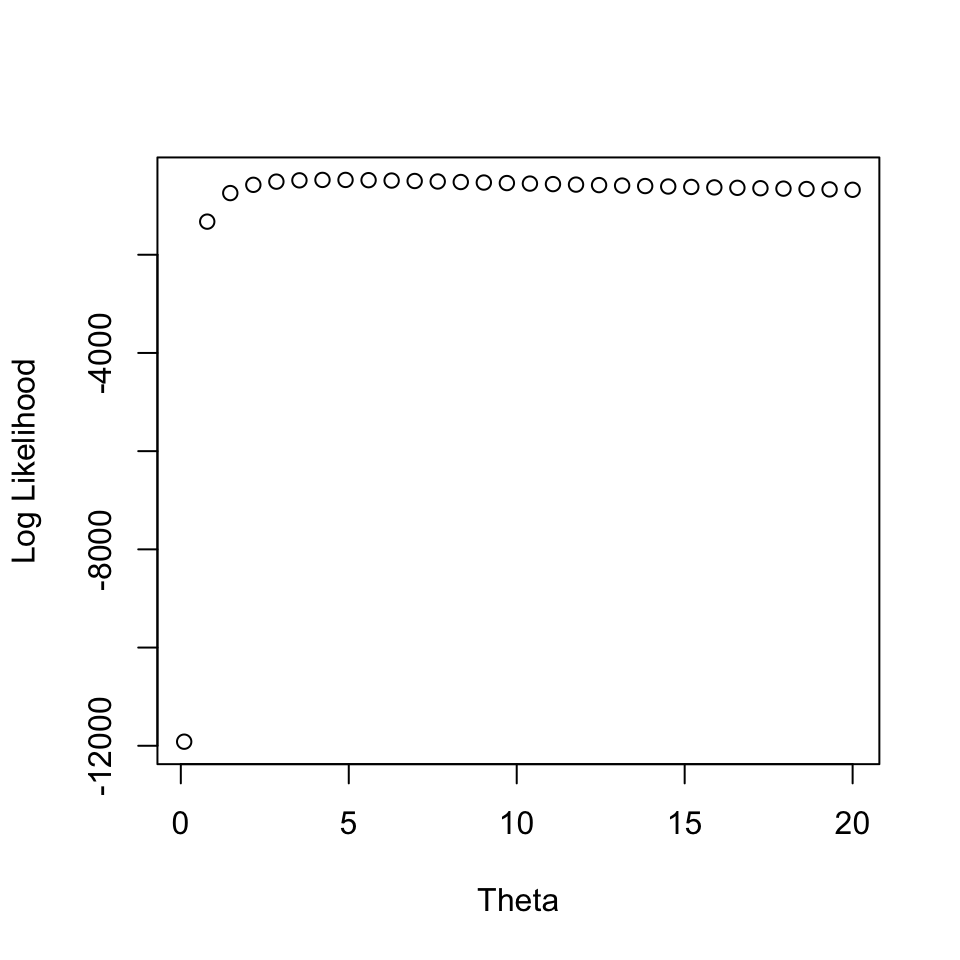

```
#> [1] "The MLE for theta is:  4.21724137931034"
```

## c. Using the MLE value of $\theta$ from part b, compute the estimated density at a set of evaluation points between 0 and 8 meters. Plot the estimated density.

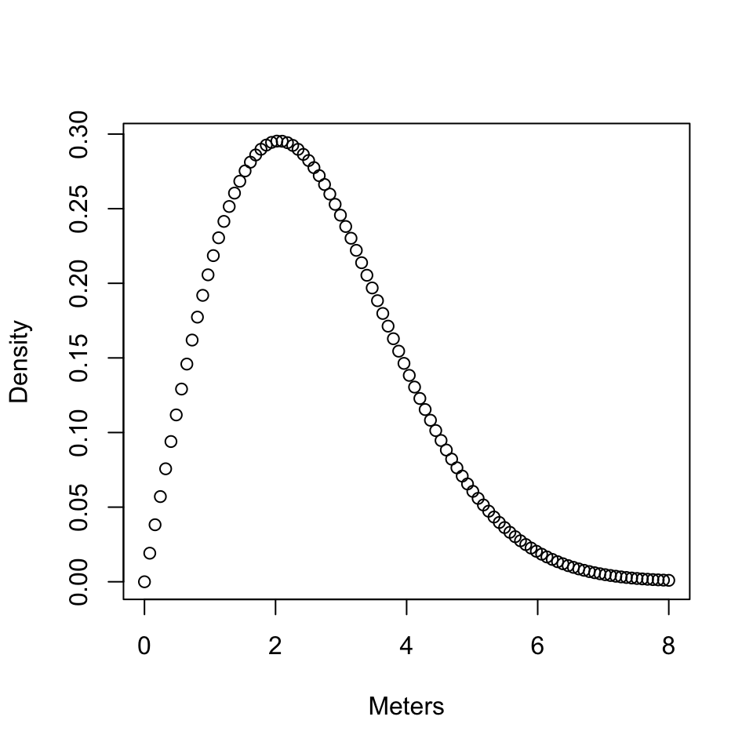

```r
## Plot sequence of x values between 0-8 to see density

x.seq=seq(0,8,length=100)

prob=numeric(length(x.seq))
for(i in 1:length(x.seq)){
  pfunction=(x.seq[i]/theta_MLE)*exp(-(x.seq[i]^2)/(2*theta_MLE))
  prob[i]=pfunction
}
result=tibble(x=x.seq,
              probability=prob)
plot(result$x, result$probability, xlab="Meters", ylab="Density")
```

```r
#hist(df$meters)
```

## d. Estimate the density using KDE. Report the bandwidth you chose and produce a plot of the estimated density.

## Lower case h for univariate

## Upper case H for MV

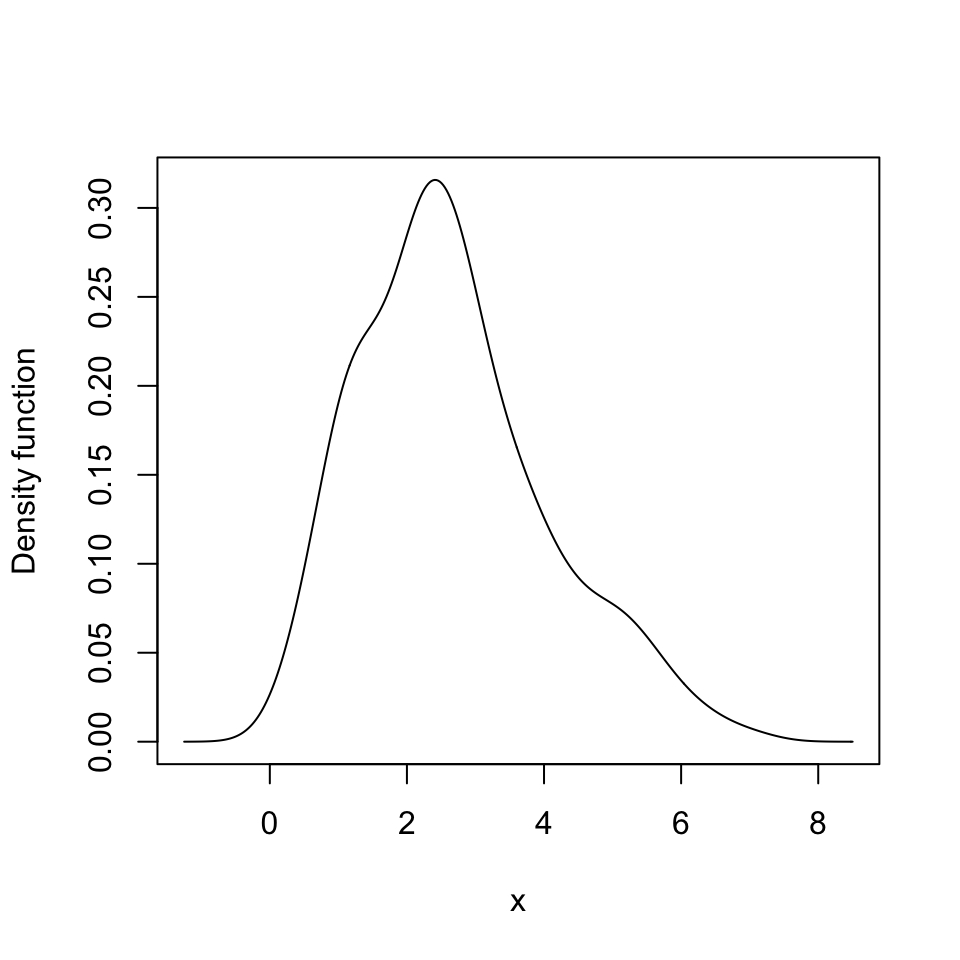

```
#> [1] "Bandwith was chosen using HPI method:  0.391020588431455"
```

## e. Which model do you prefer, the parametric or KDE?

I prefer the KDE model because it provides more granularity than the parametric model through providing local density around each point, rather than applying a uniform or rigid parametric function that applies equal density weights around each point.

# Problem 2: Interstate Crash Density

Interstate 64 (I-64) is a major east-west road that passes just south of Charlottesville. Where and when are the most dangerous places/times to be on I-64? The crash data (link below) gives the mile marker and fractional time-of-week for crashes that occurred on I-64 between mile marker 87 and 136 in 2016. The time-of-week data takes a numeric value of *<dow>.<hour/24>*, where the dow starts at 0 for Sunday (6 for Sat) and the decimal gives the time of day information. Thus `time=0.0417` corresponds to Sun at 1am and `time=6.5` corresponds to Sat at noon.

- **Crash Data**: https://mdporter.github.io/DS6030/data//crashes16.csv

## a. Extract the crashes and make a scatter plot with mile marker on x-axis and time on y-axis.

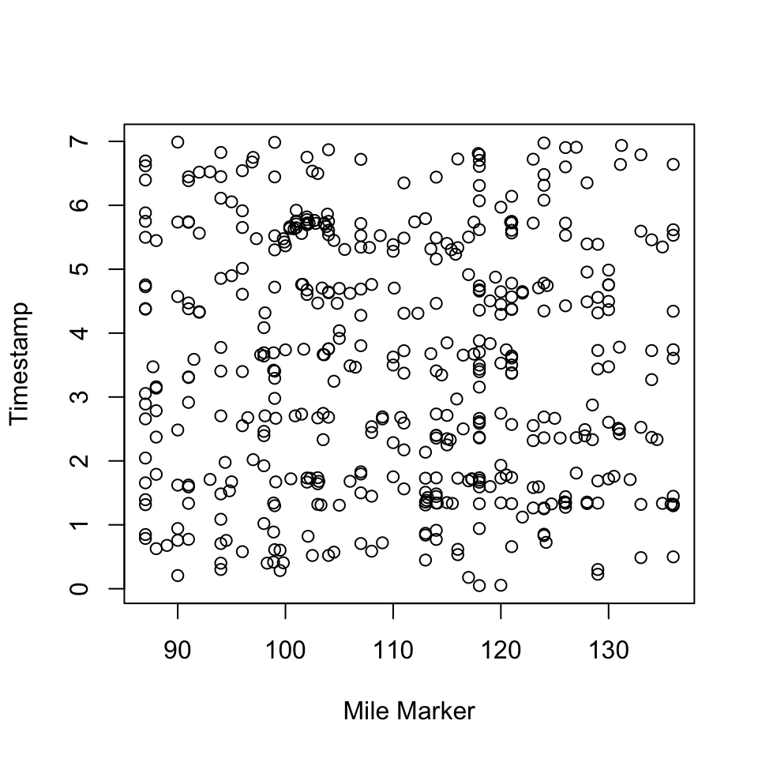

## b. Use KDE to estimate the *mile marker* density.

- Report the bandwidth.
- Plot the density estimate.

```r
## Bandwidth

b.kde=kde(df2$mile)
paste("Bandwith was chosen using HPI method: ", b.kde$h)
```

```
#> [1] "Bandwith was chosen using HPI method:  2.89409234862907"
```

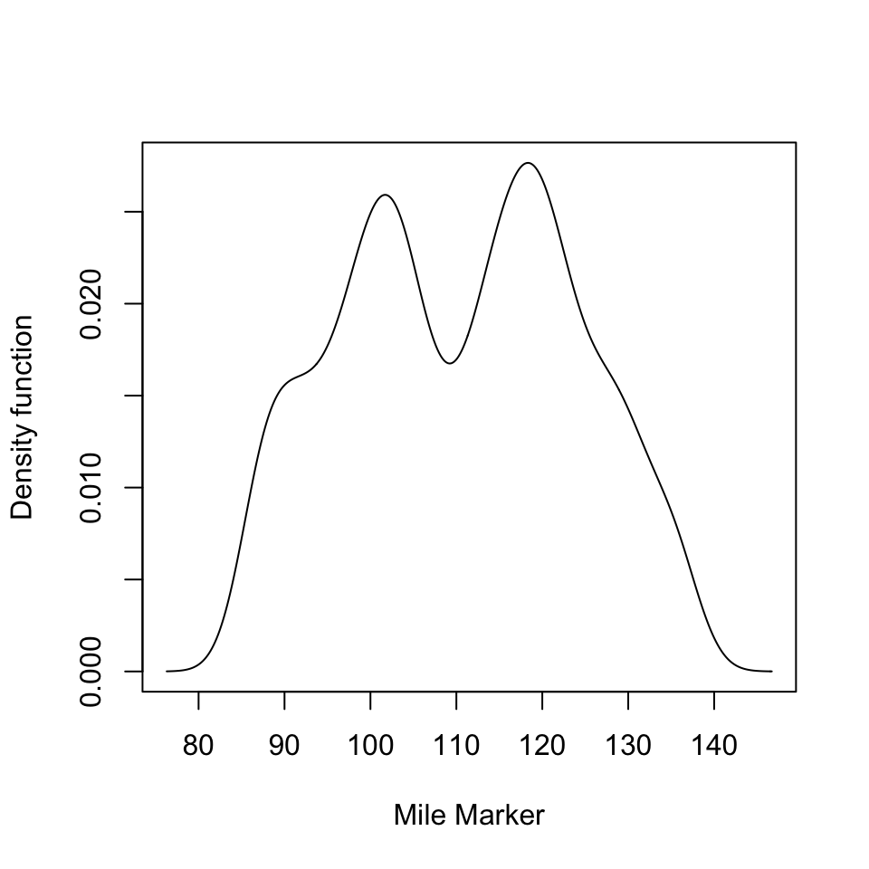

```r
## KDE estimate

plot(b.kde, xlab="Mile Marker")
```

## c. Use KDE to estimate the temporal *time-of-week* density.

- Report the bandwidth.
- Plot the density estimate.

```r
## Bandwidth

c.kde=kde(df2$time)
paste("Bandwith was chosen using HPI method: ", c.kde$h)
```

```
#> [1] "Bandwith was chosen using HPI method:  0.41412697073861"
```

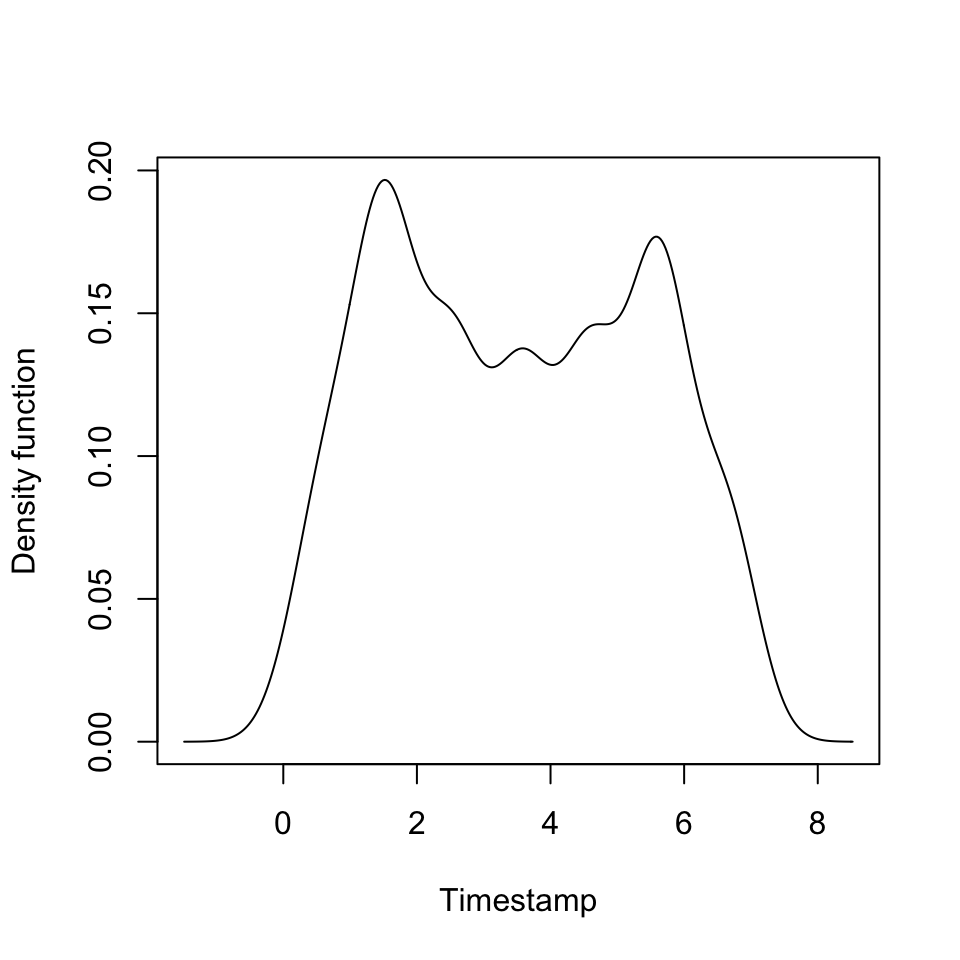

```r
## KDE estimate

plot(c.kde, xlab="Timestamp")
```

## d. Use KDE to estimate the bivariate mile-time density.

- Report the bandwidth parameters.
- Plot the bivariate density estimate.

```r
## Bandwidth

d.kde=kde(df2)
d.kde$H
```

```
#>         [,1]    [,2]
#> [1,] 19.0452 -0.1147
#> [2,] -0.1147  0.3296
```

```r
paste("Bandwith was chosen using HPI method: ", d.kde$H)
```

```
#> [1] "Bandwith was chosen using HPI method:  19.0452087786605"
#> [2] "Bandwith was chosen using HPI method:  -0.114711017864182"
#> [3] "Bandwith was chosen using HPI method:  -0.114711017864182"
#> [4] "Bandwith was chosen using HPI method:  0.329571889898206"
```

```r
print(d.kde$H)
```

```
#>         [,1]    [,2]
#> [1,] 19.0452 -0.1147
#> [2,] -0.1147  0.3296
```

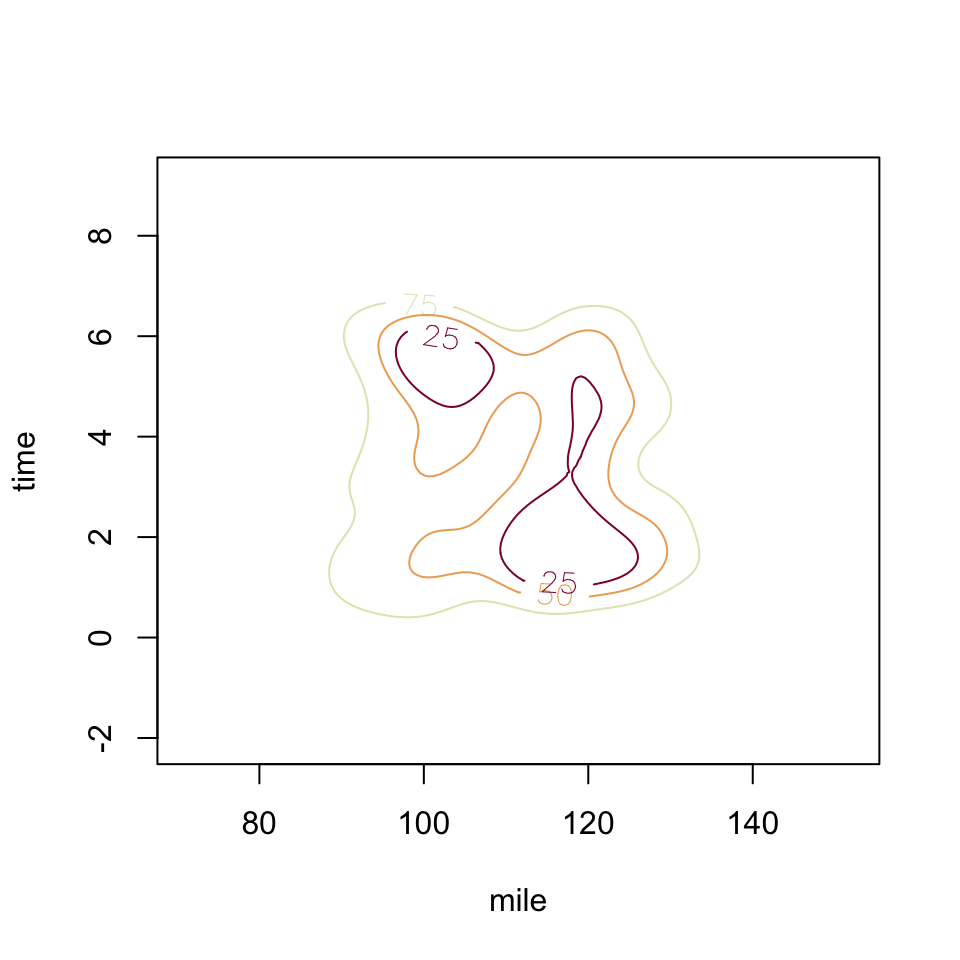

```r
## Density plot

plot(d.kde)
```

## e. Based on the estimated density, approximate the most dangerous mile marker and time-of-week.

```r
## Milemark with highest probability of crashes (indp. of time)

b.kde$eval.points[which.max(b.kde$estimate)]
```

```
#> [1] 118.4
```

```r
## Time with highest probability of crashes (indp. of milemarker)

c.kde$eval.points[which.max(c.kde$estimate)]
```

```
#> [1] 1.518
```